# Regularized linear models for predicting the battery capacity of a mobile phone from its specifications

*This is a personal introductory R notebook created for the purpose of enhancing my knowledge and skills in R, and more generally, statistical programming.*

# Introduction

In this notebook, I will be investigating the relationship between the battery capacity of modern mobile phones, and the other specifications of the same phone—such as:

- Front and rear camera resolution (megapixels)
- Screen height and width
- Weight
- Number of processor cores
- Internal memory and RAM, etc.

The battery capacity of a mobile phone is intuitively dependent upon some of these variables, such as the number of processor cores (since more cores will consume more power). However, for other variables such as the dimensions and weight of a mobile phone, this relationship may not be as clear.

As such, this notebook aims to provide exploratory analysis of the specifications of the phone, how they correlate with each other, and the battery capacity—as well as modeling the relationship.

## Linear modeling

As the variable being modeled (battery capacity) is a real-valued number, the linear model seemed most applicable to this scenario. This is ideal since linear models are often used as a simple introduction to programming in R, using functions or packages such as `lm` or `glmnet`.

There are many resources dedicated to the teaching of linear models and linear regression, so I will not cover this to its full extent.

Through linear regression, we will attempt to learn a model that expresses the battery capacity of a mobile phone as a linear combination of its specifications—that is:

$$\text{Capacity}=\theta_0+\theta_1\text{FrontCam}+\theta_2\text{BackCam}+\cdots+\theta_{n-1}\text{Weight}+\theta_n\text{RAM}$$
Where the specifications are the **explanatory variables** for our linear model, and the battery capacity is the **output variable**.

## Dataset and specifications

As expected, a mobile phone may have many specifications that its battery capacity might be dependent upon (some examples given above).

The particular dataset we will be dealing with is the [*Mobile Price Classification* dataset](https://www.kaggle.com/iabhishekofficial/mobile-price-classification) from Kaggle, by [Abhishek Sharma](https://www.kaggle.com/iabhishekofficial). This dataset is designed for modeling mobile phone prices, but since the price variable is not real-valued, I opted for battery capacity as the output variable.

The dataset consists of instances of **22** variables (including the battery capacity and ID):

| Name | Type | Description |
| --- | --- | --- |
| `id` | Numeric | The auto-incrementing ID for each phone in the dataset |
| `battery_power` | Numeric | Total energy a battery can store in one time (measured in mAh) |
| `blue` | Boolean | Whether the phone has Bluetooth support or not |
| `clock_speed` | Numeric | Speed at which microprocessor executes instructions |
| `dual_sim` | Boolean | Whether the phone has dual-SIM support or not |
| `fc` | Numeric | Front camera megapixels |
| `four_g` | Boolean | Whether the phone has 4G support or not |
| `int_memory` | Numeric | Internal memory in gigabytes |
| `m_dep` | Numeric | Mobile depth in centimetres |
| `mobile_wt` | Numeric | Weight of mobile phone in grams |
| `n_cores` | Numeric | Number of processor cores |
| `pc` | Numeric | Primary camera megapixels |
| `px_height` | Numeric | Pixel resolution (height) |
| `px_width` | Numeric | Pixel resolution (width) |
| `ram` | Numeric | Random Access Memory in megabytes |
| `sc_h` | Numeric | Screen height in centimetres |
| `sc_w` | Numeric | Screen width in centimetres |
| `talk_time` | Numeric | Longest time that a single battery charge will last when you are on a call |
| `three_g` | Boolean | Whether the phone has 3G support or not |
| `touch_screen` | Boolean | Whether the phone has a touch screen or not |
| `wifi` | Boolean | Whether the phone has a WiFi adapter or not |
| `price_range` | Numeric | Target variable with value of 0 (low cost), 1 (medium cost), 2 (high cost) and 3 (very high cost) |

For our purposes, the `id` and `price_range` variables are not necessary—reducing the dataset to the battery capacity output variable and **19** explanatory specification variables.

## Setup

Installing and requiring dependencies and additional files:

```r
# Set working directory
setwd('~/Downloads/R/reg-lm')

# Install dependencies
#install.packages("glmnet")
#install.packages("glmnetUtils")
#install.packages("ggplot2")
#install.packages("GGally")

# Require dependencies
require(readr)
require(glmnet)
require(glmnetUtils)
require(ggplot2)
require(GGally)

# Set seed for reproducibility
set.seed(9292)
```

Importing the training and test sets, ignoring the unnecessary features:

```r
# Import train + test sets
train <- read_csv('data/train.csv')[,1:20] # Ignore price_range
test <- read_csv('data/test.csv')[,2:21] # Ignore ID
```

## Exploratory analysis of the training set

To understand the extent to which the variables of the dataset correlate with each other, our first step is to visualize the **correlation matrix** of the training data.

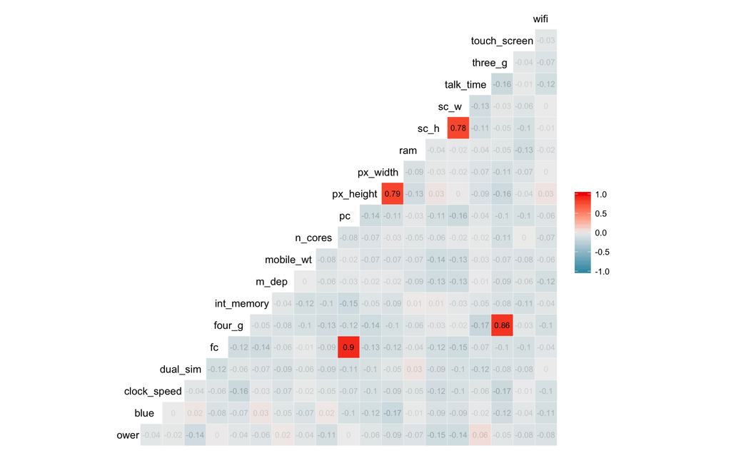

```r
# Correlation plot of all variables (including output)
ggcorr(cor(train), label=TRUE, label_size=3, label_round=2, label_alpha=TRUE, hjust=0.85)
```

As evident from the correlation plot, there are a number of very highly-correlated explanatory variables—namely the pairs:

- `px_height` and `px_width`: Mobile phone resolutions are normally selected from a fixed number of commonly used options for dimensions such as 480×800, 640×1136, 720×1280, 750×1334, 1080×1920, and 1440×2560.
- `sc_h` and `sc_w`: It is intuitive that an increase in phone screen height necessitates an increase in width—barring exceptional cases such as the BlackBerry Passport or older narrow Nokia phones.
- `pc` and `fc`: A phone with a very high megapixel primary camera is unlikely to have a significantly low megapixel front camera, nor higher than the primary camera. This pattern seems to hold for most phones except those with far better primary camera. One example of such a phone is the Nokia Lumia 1020, with a 41-megapixel primary camera and a 1.2-megapixel front camera. In comparison, the HTC One has a 4-megapixel primary camera and a 2.1-megapixel front camera.
- `four_g` and `three_g`: All 4G phones will work on 3G networks, which is why these to variables are highly correlated. However, note that it is not the case that 3G phones work on 4G networks.

For simplicity of our model, we will remove the `px_width`, `sc_w`, `fc` and `four_g` variables from our training and test sets, in accordance to the explanations above. This will help our model avoid any problems due to multicollinearity, such as instability in the estimated parameters (weights):

```r
# Remove variables from training set
train$px_width <- NULL
train$sc_w <- NULL
train$fc <- NULL
train$four_g <- NULL

# Remove variables from test set
test$px_width <- NULL
test$sc_w <- NULL
test$fc <- NULL
test$four_g <- NULL

# Inspect modified training data
print(train)
```

| battery_power | blue | clock_speed | dual_sim | int_memory | m_dep | mobile_wt | n_cores | pc | px_height | ram | sc_h | talk_time | three_g | touch_screen | wifi |
| --- | --- | --- | --- | --- | --- | --- | --- | --- | --- | --- | --- | --- | --- | --- | --- |
| 842 | 0 | 2.2 | 0 | 7 | 0.6 | 188 | 2 | 2 | 20 | 2549 | 9 | 19 | 0 | 0 | 1 |
| 1021 | 1 | 0.5 | 1 | 53 | 0.7 | 136 | 3 | 6 | 905 | 2631 | 17 | 7 | 1 | 1 | 0 |
| 563 | 1 | 0.5 | 1 | 41 | 0.9 | 145 | 5 | 6 | 1263 | 2603 | 11 | 9 | 1 | 1 | 0 |
| 615 | 1 | 2.5 | 0 | 10 | 0.8 | 131 | 6 | 9 | 1216 | 2769 | 16 | 11 | 1 | 0 | 0 |
| 1821 | 1 | 1.2 | 0 | 44 | 0.6 | 141 | 2 | 14 | 1208 | 1411 | 8 | 15 | 1 | 1 | 0 |
| 1859 | 0 | 0.5 | 1 | 22 | 0.7 | 164 | 1 | 7 | 1004 | 1067 | 17 | 10 | 1 | 0 | 0 |
| 1821 | 0 | 1.7 | 0 | 10 | 0.8 | 139 | 8 | 10 | 381 | 3220 | 13 | 18 | 1 | 0 | 1 |
| 1954 | 0 | 0.5 | 1 | 24 | 0.8 | 187 | 4 | 0 | 512 | 700 | 16 | 5 | 1 | 1 | 1 |
| 1445 | 1 | 0.5 | 0 | 53 | 0.7 | 174 | 7 | 14 | 386 | 1099 | 17 | 20 | 1 | 0 | 0 |
| 509 | 1 | 0.6 | 1 | 9 | 0.1 | 93 | 5 | 15 | 1137 | 513 | 19 | 12 | 1 | 0 | 0 |

[output cut: 990 more lines]

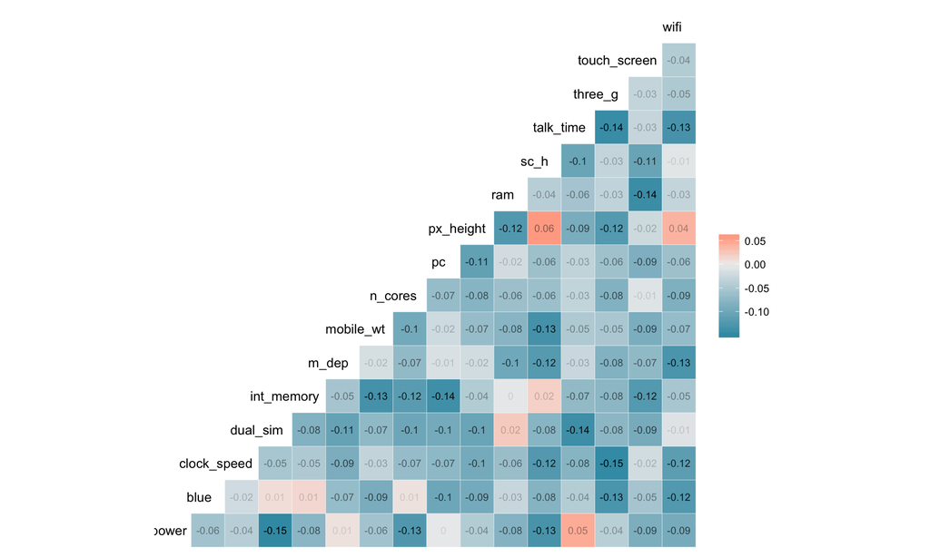

```r
# Re-display the correlation matrix for the modified training data
ggcorr(cor(train), label=TRUE, label_size=3, label_round=2, label_alpha=TRUE, hjust=0.85, limits=FALSE)
```

The adjusted scale now allows us to more clearly understand the correlations of the variables—especially the correlations of `battery_power` with the explanatory variables.

Interestingly, there appears to be relatively strong negative correlations with `dual_sim`, `n_cores` and `sc_h`.

- `dual_sim`: Dual-SIM phones normally would consume more power than their single-SIM counterpart. [As explained here](https://www.quora.com/Do-the-dual-SIM-phones-consume-more-battery-compared-to-the-single-SIM-phones-for-an-observed-unit-of-time), dual-SIM phones can often have both SIMs active, which would consume more power. As a result, it would be expected to see at least a very weak positive correlation with `battery_power`, but it appears to be a negative one.
- `n_cores`: The number of processor cores would perhaps be expected to be one of the more influencing factors on the battery power of a phone, since the processor is the main component of a phone, and likely consumes the most power. However, with this data, this correlation appears to be a relatively strong negative one, which is very dubious.
- `sc_h`: Considering the fact that there are many older phones which are tall but with lower battery power, such as Nokia XpressMusic 5310, a negative correlation might be expected. However, the actual screen heights of such phones are still small, as the keyboards generally occupied most of the space on the phone. Another factor to consider is that screen heights may not have changed much in the last few years, but smartphones have gotten wider, and thus are still able to support larger batteries whilst maintaining the same height as older phones.

Nevertheless, we will proceed to separate the output variable from the explanatory variables:

```r
# Separate explanatory and output variables
train.X <- as.matrix(train[,-1]) # Explanatory
train.y <- as.double(as.matrix(train[, 1])) # Output
test.X <- as.matrix(test[,-1]) # Explanatory
test.y <- as.double(as.matrix(test[, 1])) # Output
```

View training data dimensions:

```r
cat(sprintf("Training data shape: (%s, %s)\n", nrow(train.X), ncol(train.X)))
```

```
Training data shape: (2000, 15)
```

```r
cat(sprintf("Training labels shape: (%s, 1)\n", length(train.y)))
```

```
Training labels shape: (2000, 1)
```

# Training the linear models

We will consider four forms of linear regression for the training of the models:

- Unregularized regression (baseline)
- $L_1$-regularized (LASSO) regression
- $L_2$-regularized (Ridge) regression
- ElasticNet-regularized regression

## Unregularized (Basic) regression

In unregularized linear regression, we simply find the optimal weights that minimise the cost function $C(\boldsymbol{\theta})$, which is given as the **residual sum-squared error function** (RSS):
$$\begin{align}
C(\boldsymbol{\theta})
&=\sum_{i=1}^n\left(y^{(i)}-\hat{y}^{(i)}\right)^2\\
&=\sum_{i=1}^n\left(y^{(i)}-\boldsymbol{\theta}^\mathsf{T} \mathbf{x}^{(i)}\right)^2
\end{align}$$
Making the minimization problem for the optimal weights:
$$\begin{align}
\hat{\boldsymbol{\theta}}
&=\arg\min_{\boldsymbol{\theta}\in\boldsymbol{\Theta}}C(\boldsymbol{\theta})\\
&=\arg\min_{\boldsymbol{\theta}\in\boldsymbol{\Theta}}\sum_{i=1}^n\left(y^{(i)}-\boldsymbol{\theta}^\mathsf{T} \mathbf{x}^{(i)}\right)^2
\end{align}$$
The `glm` function solves this minimization problem and fits a linear model with the optimal weights:

```r
# Fit a linear model
basic.lm <- glm(train.y ~ train.X)

# View the weights
basic.weights <- basic.lm$coefficients
print(basic.weights)
```

```
        (Intercept)         train.Xblue  train.Xclock_speed
       1.208024e+03        1.200095e+01        6.678271e+00
    train.Xdual_sim   train.Xint_memory        train.Xm_dep
      -3.504496e+01       -1.097526e-01        4.641816e+01
   train.Xmobile_wt      train.Xn_cores           train.Xpc
      -2.564217e-02       -6.000733e+00        2.149487e+00
   train.Xpx_height          train.Xram         train.Xsc_h
       1.710654e-02        2.950808e-05       -3.105404e+00
   train.Xtalk_time      train.Xthree_g train.Xtouch_screen
       4.079951e+00        1.558460e+01       -1.111156e+01
        train.Xwifi
      -4.352294e+00
```

### Evaluation

The goodness of fit for a linear model can be evaluated with the **root mean squared error** (RMSE) function, which is a similar measure to RSS:
$$\begin{align}
\text{RMSE}
&=\sqrt{\frac{1}{n}\sum_{i=1}^n\left(y^{(i)}-\hat{y}^{(i)}\right)^2}\\
&=\sqrt{\frac{1}{n}\sum_{i=1}^n\left(y^{(i)}-\boldsymbol{\theta}^\mathsf{T} \mathbf{x}^{(i)}\right)^2}
\end{align}$$
This can easily be calculated for the dataset with a custom function:

```r
# Function for calculating the root mean squared error
rmse <- function(y_pred, y) return(sqrt(mean((y_pred-y)^2)))
```

```r
# Calculate the RMSE training error
basic.train_rmse <- rmse(predict(basic.lm, newdata=list(X=train.X)), train.y)
cat(sprintf("Training error (RMSE): %s\n", basic.train_rmse))
```

```
Training error (RMSE): 437.317934378211
```

```r
# Calculate the RMSE test error
basic.test_rmse <- rmse(predict(basic.lm, newdata=list(X=test.X)), test.y)
cat(sprintf("Test error (RMSE): %s\n", basic.test_rmse))
```

```
Test error (RMSE): 434.465861452291
```

## $L_1$-regularized (LASSO) regression

Regularization of linear regression problems aims to reduce the *complexity* of a model, making it overfit to the training data less.

This is done by modifying the cost function with an additional **regularization term**. In the case of $L_1$-regularized linear regression, this term comes in the form of the $L_1$-norm (also known as Manhattan distance):
$$\begin{align}
C(\boldsymbol{\theta})
&=\sum_{i=1}^n\left(y^{(i)}-\hat{y}^{(i)}\right)^2+\lambda\color{blue}{\sum_{i=1}^n |\theta_i|}\\
&=\sum_{i=1}^n\left(y^{(i)}-\boldsymbol{\theta}^\mathsf{T} \mathbf{x}^{(i)}\right)^2+\lambda\color{blue}{||\boldsymbol{\theta}||_1}
\end{align}$$
The minimization problem now incorporates the additional $\lambda$ variable, which controls how much penalization there is to the RSS function. $\lambda$ is often chosen through cross-validation to minimise a particular *measure of fit*—in this case, **mean squared error** (MSE), which is the square of the previously seen RMSE.

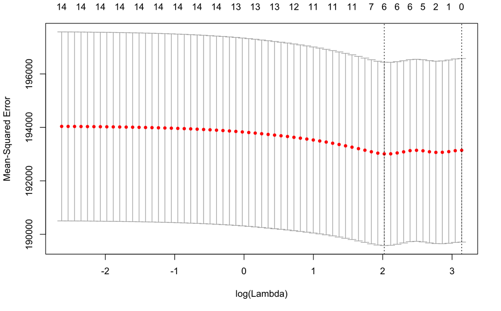

```r
# Cross-validated tuning parameter search (MSE)
# NOTE: alpha=1 corresponds to L1 regularization
lasso.cv <- cv.glmnet(train.X, train.y, alpha=1, type.measure="mse", nfolds=25, standardize=TRUE)

# Visualize the varying lambda values and their measures of fit
plot(lasso.cv)
```

The value represented by the rightmost dotted line is the (log) lambda that created the most regularized model such that error is within one standard error of the minimum. This can be accessed as `lasso.cv$lambda.1se`.

The value represented by the leftmost dotted line is the lambda that created the model such that the error was minimized. This can be accessed as `lasso.cv$lambda.min`. This is the lambda that we will use to fit our regularized linear model.

We can retrieve the optimal $\lambda$ from this `cv.glmnet` object:

```r
# Retrieve the optimal lambda selected from the cross-validation
lasso.lambda <- lasso.cv$lambda.min
cat(sprintf("Optimum lambda: %s\n",lasso.lambda))
```

```
Optimum lambda: 7.55380749973438
```

Training the regularized linear model and viewing the weights:

```r
# Fit a linear model with the cross-validated lambda parameter
lasso.lm <- glmnet(train.X, train.y, alpha=1, lambda=lasso.lambda)

# View the regularized weights
lasso.weights <- coef(lasso.lm)
print(lasso.weights)
```

```
16 x 1 sparse Matrix of class "dgCMatrix"
                       s0
(Intercept)  1225.2920919
blue            .
clock_speed     .
dual_sim      -20.4191656
int_memory      .
m_dep          23.0087655
mobile_wt       .
n_cores        -2.5903738
pc              0.9417839
px_height       .
ram             .
sc_h           -1.2660410
talk_time       2.7278579
three_g         .
touch_screen    .
wifi            .
```

LASSO is able to shrink the weights of features which are irrelevant to the model, to zero—as seen with the weights of explanatory variables `blue`, `clock_speed`, `int_memory`, `mobile_wt`, `px_height`, `ram`, `three_g`, `touch_screen` and `wifi`, being reduced to zero. This effectively makes LASSO a form of feature selection prior to training the model.

If we look back at the correlation matrix, we can see that LASSO did indeed keep all of the features which had a high absolute-value correlation, like `dual_sim`, `n_cores` and `sc_h`, along with a few other features.

### Evaluation

```r
# Calculate the RMSE training error
lasso.train_rmse <- rmse(predict(lasso.lm, train.X), train.y)
cat(sprintf("Training error (RMSE): %s\n", lasso.train_rmse))
```

```
Training error (RMSE): 437.911745025098
```

```r
# Calculate the RMSE test error
lasso.test_rmse <- rmse(predict(lasso.lm, test.X), test.y)
cat(sprintf("Test error (RMSE): %s\n", lasso.test_rmse))
```

```
Test error (RMSE): 431.820735533246
```

## $L_2$-regularized (Ridge) regression

In $L_2$ regularized least square problems, the regularization term is in the form of the squared $L_2$ norm (Euclidean distance):

$$\begin{align}
C(\boldsymbol{\theta})
&=\sum_{i=1}^n\left(y^{(i)}-\hat{y}^{(i)}\right)^2+\lambda\color{blue}{\sum_{i=1}^n \theta_i^2}\\
&=\sum_{i=1}^n\left(y^{(i)}-\boldsymbol{\theta}^\mathsf{T} \mathbf{x}^{(i)}\right)^2+\lambda\color{blue}{||\boldsymbol{\theta}||_2^2}
\end{align}$$
To find the optimal $\lambda$, we can use `cv.glmnet` again:

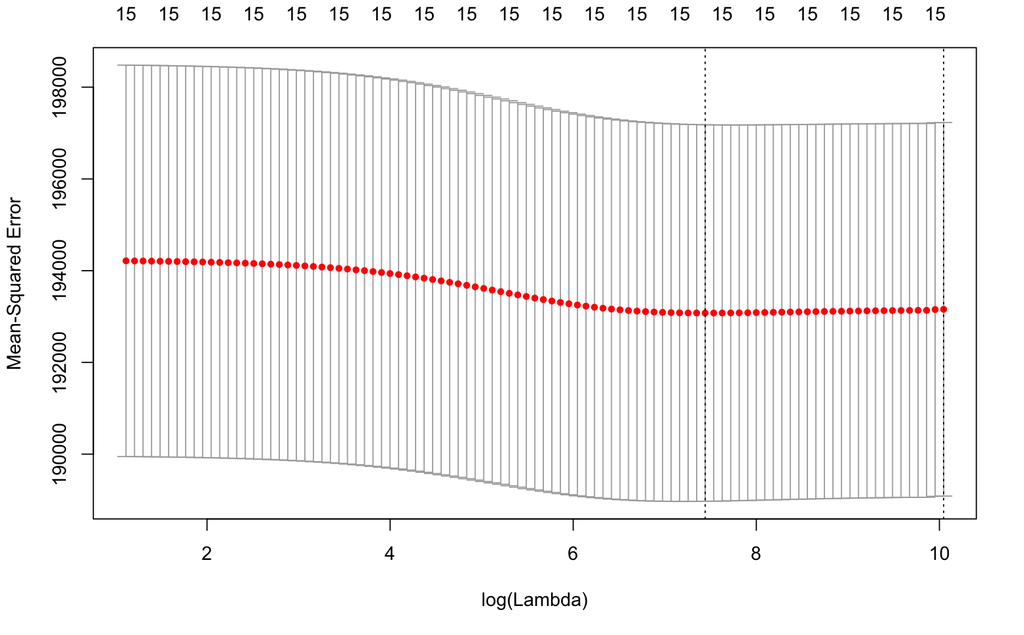

```r
# Cross-validated tuning parameter search (MSE)
# NOTE: alpha=0 corresponds to L2 regularization
ridge.cv <- cv.glmnet(train.X, train.y, alpha=0, type.measure="mse", nfolds=25, standardize=TRUE)

# Visualize the varying lambda values and their measures of fit
plot(ridge.cv)
```

Retrieving the optimal $\lambda$:

```r
# Retrieve the optimal lambda selected from the cross-validation
ridge.lambda <- ridge.cv$lambda.min
cat(sprintf("Optimum lambda: %s\n", ridge.lambda))
```

```
Optimum lambda: 1704.90925088544
```

Training the regularized linear model and viewing the weights:

```r
# Fit a linear model with the cross-validated lambda parameter
ridge.lm <- glmnet(train.X, train.y, lambda=ridge.lambda, alpha=0)

# View the regularized weights
ridge.weights <- coef(ridge.lm)
print(ridge.weights)
```

```
16 x 1 sparse Matrix of class "dgCMatrix"
                        s0
(Intercept)   1.231338e+03
blue          2.108933e+00
clock_speed   1.283200e+00
dual_sim     -7.450544e+00
int_memory   -2.008655e-02
m_dep         1.039360e+01
mobile_wt     2.626740e-03
n_cores      -1.182211e+00
pc            4.608123e-01
px_height     3.118111e-03
ram          -3.854202e-05
sc_h         -6.376470e-01
talk_time     8.578839e-01
three_g       2.586136e+00
touch_screen -1.966777e+00
wifi         -1.369582e+00
```

Unlike LASSO, Ridge regression will not shrink any weights to zero (as seen above), it instead treats all explanatory variables as having **some** level of contribution to the output variable. However, it is still capable of reducing weights to very small numbers that are essentially negligible.

### Evaluation

```r
# Calculate the RMSE training error
ridge.train_rmse <- rmse(predict(ridge.lm, train.X), train.y)
cat(sprintf("Training error (RMSE): %s\n", ridge.train_rmse))
```

```
Training error (RMSE): 438.566735307773
```

```r
# Calculate the RMSE test error
ridge.test_rmse <- rmse(predict(ridge.lm, test.X), test.y)
cat(sprintf("Test error (RMSE): %s\n", ridge.test_rmse))
```

```
Test error (RMSE): 432.015448047766
```

## ElasticNet-regularized regression

ElasticNet regularization is a method that combines both the $L_1$ and $L_2$ norms to form a cost function that is a compromise of both functions. This allows for a regularization method that comes with a combination of benefits of both norms, and makes the disadvantages of either norm less significant.

This is done through the introduction of a **mixing parameter** $\alpha$, which controls the weight of the penalty on either norm:

$$\begin{align}
C(\boldsymbol{\theta})
&=\sum_{i=1}^n\left(y^{(i)}-\hat{y}^{(i)}\right)^2+\lambda\Bigg(\alpha\overbrace{\sum_{i=1}^n |\theta_i|}^{L_1}+\frac{1-\alpha}{2}\overbrace{\sum_{i=1}^n\theta_i^2 }^{L_2}\ \Bigg)\\
&=\sum_{i=1}^n\left(y^{(i)}-\boldsymbol{\theta}^\mathsf{T} \mathbf{x}^{(i)}\right)^2+\lambda\left(\alpha||\boldsymbol{\theta}||_1+\frac{1-\alpha}{2}||\boldsymbol{\theta}||_2\right)
\end{align}$$

For example, $\alpha=1$ corresponds to $L_1$ (LASSO) regression and $\alpha=0$ corresponds to $L_2$ (Ridge) regression. Anything between these two values is a mixture of the two.

However, the introduction of a second parameter makes cross-validation more complicated. `cva.glmnet` allows us to find an optimal $\alpha$ and $\lambda$:

```r
# Vector of alpha values to cross-validate on
alphas <- seq(0, 1, len = 12)^3
print(alphas)
```

```
 [1] 0.0000000000 0.0007513148 0.0060105184 0.0202854996 0.0480841473
 [6] 0.0939143501 0.1622839970 0.2577009767 0.3846731781 0.5477084899
[11] 0.7513148009 1.0000000000
```

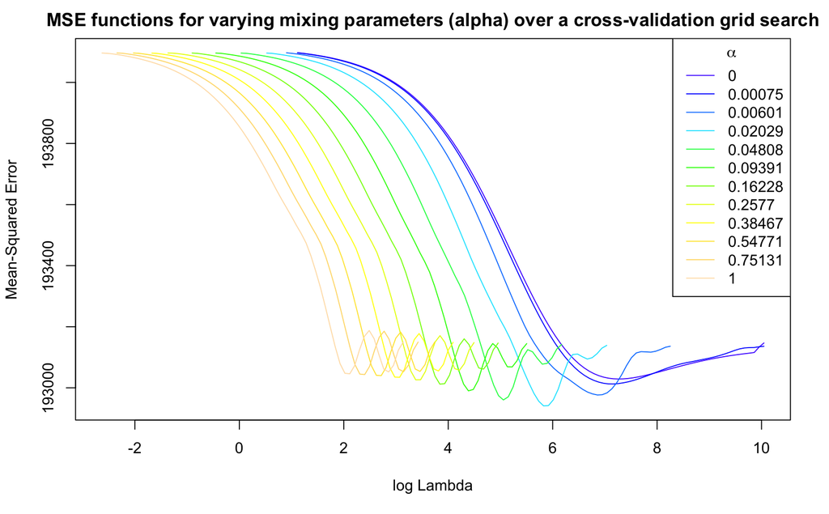

```r
# Cross-validated tuning parameter search (MSE)
elastic.cva <- cva.glmnet(train.X, train.y, alpha=alphas, type.measure="mse", nfolds=25, standardize=TRUE)

# Visualize the varying lambda values and their measures of fit for each alpha
plot(elastic.cva,
     main=c("MSE functions for varying mixing parameters (alpha) over a cross-validation grid search"))
legend('topright', legend=round(alphas, digits=5), title=expression(alpha),
       col=topo.colors(length(alphas)), lty=1)
```

Despite the `cva.glmnet` function being able to perform a grid search over $\lambda$ and $\alpha$ for cross-validation, there appears to be no simple way to retrieve the optimal parameters from the `cva.glmnet` object.

Therefore we must manually iterate through the individual `cv.glmnet` objects (one for each possible alpha value) stored within the `cva.glmnet` object, `elastic.cva`. Each individual `cv.glmnet` object can be accessed with `elastic.cva$modlist[[i]]`, where `i` is an index representing one of the `alphas`. For example:

```r
# View the first cv.glmnet object, representing the first alpha
summary(elastic.cva$modlist[[1]])
```

```
           Length Class  Mode
lambda     97     -none- numeric
cvm        97     -none- numeric
cvsd       97     -none- numeric
cvup       97     -none- numeric
cvlo       97     -none- numeric
nzero      97     -none- numeric
name        1     -none- character
glmnet.fit 12     elnet  list
lambda.min  1     -none- numeric
lambda.1se  1     -none- numeric
```

Retrieving the optimal $\alpha$ and $\lambda$:

```r
idx <- -1 # Index of the model with the lowest MSE
min_mse <- .Machine$integer.max # The lowest MSE

for (i in 1:length(alphas)) {
  # The current alpha
  alpha.i <- alphas[i]
  # The lambda for the current alpha, that minimises mean CV error
  lambda.i <- elastic.cva$modlist[[i]]$lambda.min
  # Create a model with alpha and the corresponding lambda
  model.i <- glmnet(train.X, train.y, alpha=alpha.i, lambda=lambda.i)
  # Calculate the mean squared error for the model
  mse.i <- rmse(predict(model.i, train.X), train.y)^2

  # Update variables if the current MSE is less than previous minimum MSE
  if (mse.i < min_mse) {
    idx <- i
    min_mse <- mse.i
  }
}

# Optimum cv.glmnet object
elastic.cv <- elastic.cva$modlist[[idx]]
```

```r
# View the optimum alpha
elastic.alpha <- alphas[idx]
cat(sprintf("Optimum alpha: %s\n", elastic.alpha))
```

```
Optimum alpha: 0.257700976709241
```

```r
# View the optimum lambda
elastic.lambda <- elastic.cv$lambda.min
cat(sprintf("Optimum lambda: %s\n", elastic.lambda))
```

```
Optimum lambda: 29.3122967409518
```

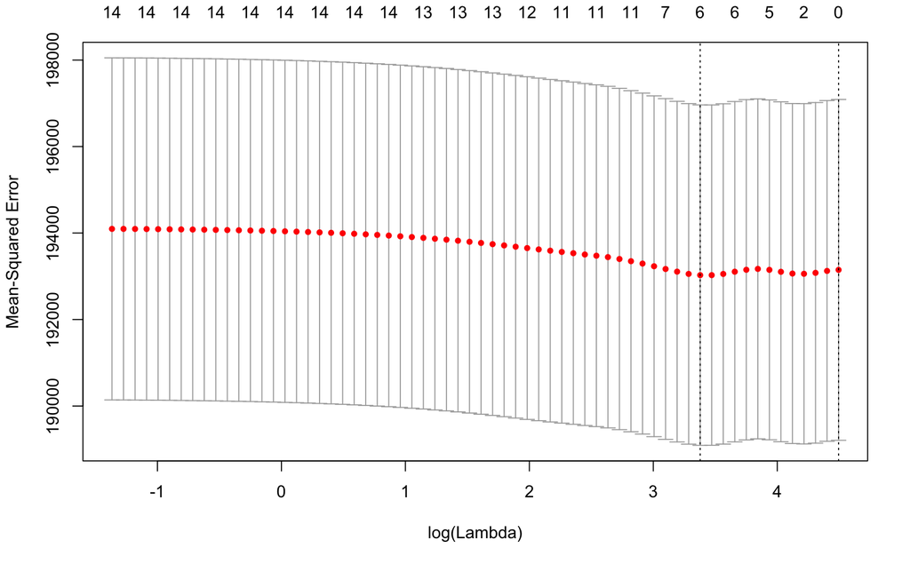

```r
# Visualize the varying lambda values and their measures of fit, for the optimal alpha
plot(elastic.cv)
```

Training the regularized linear model and viewing the weights:

```r
# Training the linear model
elastic.lm <- glmnet(train.X, train.y, alpha=elastic.alpha, lambda=elastic.lambda)

# View the regularized weights
elastic.weights <- coef(elastic.lm)
print(elastic.weights)
```

```
16 x 1 sparse Matrix of class "dgCMatrix"
                       s0
(Intercept)  1225.7930267
blue            .
clock_speed     .
dual_sim      -19.5068472
int_memory      .
m_dep          22.0393549
mobile_wt       .
n_cores        -2.4602312
pc              0.9011538
px_height       .
ram             .
sc_h           -1.2090263
talk_time       2.6037627
three_g         .
touch_screen    .
wifi            .
```

### Evaluation

```r
# Calculate the RMSE training error
elastic.train_rmse <- rmse(predict(elastic.lm, train.X), train.y)
cat(sprintf("Training error (RMSE): %s\n", elastic.train_rmse))
```

```
Training error (RMSE): 437.950788952259
```

```r
# Calculate the RMSE test error
elastic.test_rmse <- rmse(predict(elastic.lm, test.X), test.y)
cat(sprintf("Test error (RMSE): %s\n", elastic.test_rmse))
```

```
Test error (RMSE): 431.821497729024
```

# Model comparison

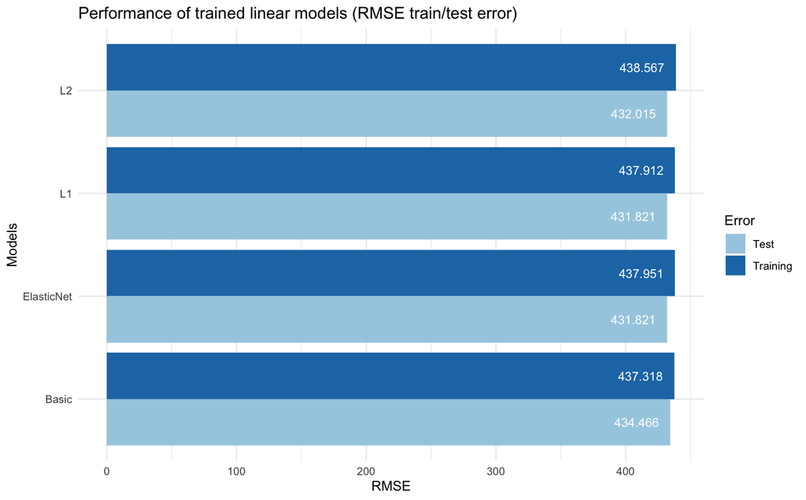

```r
# Dataframe representing the train/test RMSEs of the models
comparison <- data.frame(
  Error=rep(c("Training", "Test"), each=4),
  Models=c("Basic", "L1", "L2", "ElasticNet"),
  RMSE=round(c(basic.train_rmse, lasso.train_rmse, ridge.train_rmse, elastic.train_rmse,
         basic.test_rmse, lasso.test_rmse, ridge.test_rmse, elastic.test_rmse), digits=3)
)

# Grouped bar plot for the comparison of train/test RMSEs of each model
ggplot(data=comparison, aes(x=Models, y=RMSE, fill=Error)) +
  geom_bar(stat="identity", position="dodge") +
  geom_text(aes(label=RMSE), hjust=1.25, color="white", position = position_dodge(0.9), size=3.5) +
  scale_fill_brewer(palette="Paired") +
  theme_minimal() +
  ggtitle("Performance of trained linear models (RMSE train/test error)") +
  coord_flip()
```

## Training error

According to the RMSE measure of fit, in order of performance on the training set from best to worst (least to most RMSE):

[output not shown]

## Test error

According to the RMSE measure of fit, in order of performance on the test set from best to worst (least to most RMSE):

[output not shown]

# Future improvements

[Principal component (PC) regression](https://en.wikipedia.org/wiki/Principal_component_regression) is commonly used when there are issues with multicollinearity in the dataset.

In PC regression, instead of modeling the output variable as a linear combination of the explanatory variables, we first perform Principal Component Analysis (PCA) on the dataset, and use the chosen number of new principal components with high variances (eigenvalues) as the new regressors. This is a form of dimensionality reduction, and can be useful for reducing the number of features in very high-dimensional datasets.